# term7-project

## Exploring the data

Here we will explore the data and choose some variables to examine in further depth. The variables:

```
##  [1] "ListingKey"
##  [2] "ListingNumber"
##  [3] "ListingCreationDate"
##  [4] "CreditGrade"
##  [5] "Term"
##  [6] "LoanStatus"
##  [7] "ClosedDate"
##  [8] "BorrowerAPR"
##  [9] "BorrowerRate"
## [10] "LenderYield"
## [11] "EstimatedEffectiveYield"
## [12] "EstimatedLoss"
## [13] "EstimatedReturn"
## [14] "ProsperRating..numeric."
## [15] "ProsperRating..Alpha."
```

[output cut: 66 more lines]

```
##
##              Cancelled             Chargedoff              Completed
##                      5                  11992                  38074
##                Current              Defaulted FinalPaymentInProgress
##                  56576                   5018                    205
##   Past Due (>120 days)   Past Due (1-15 days)  Past Due (16-30 days)
##                     16                    806                    265
##  Past Due (31-60 days)  Past Due (61-90 days) Past Due (91-120 days)
##                    363                    313                    304
```

```
##
##    A   AA    B    C    D    E   HR   NC
## 3315 3509 4389 5649 5153 3289 3508  141
```

I feel that the most interesting investigation into this data would be attempting to predict whether or not a loan defaults. This is obviously a tough thing, so I will first begin by examining the characteristics of defaulted loans versus completed ones.

The first things I am going to look at are credit grade and employment status. I expect that loans that default will have a lower credit grade and/or a more precarious employment status.

By reading the documentation it is clear that loans post-January 2009 have a Prosper Rating while those before have a credit grade. Therefore I am going to combine them into one varable called ‘Rating’.

Now lets subset our data and take a look at some of the resulting plots.

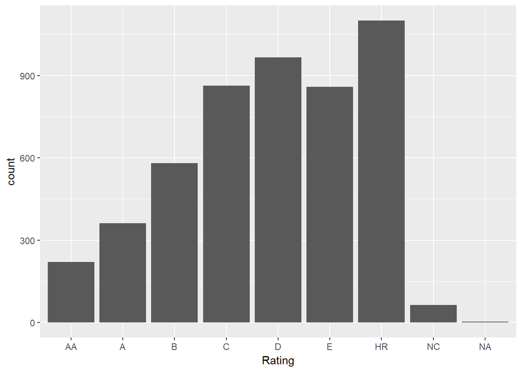

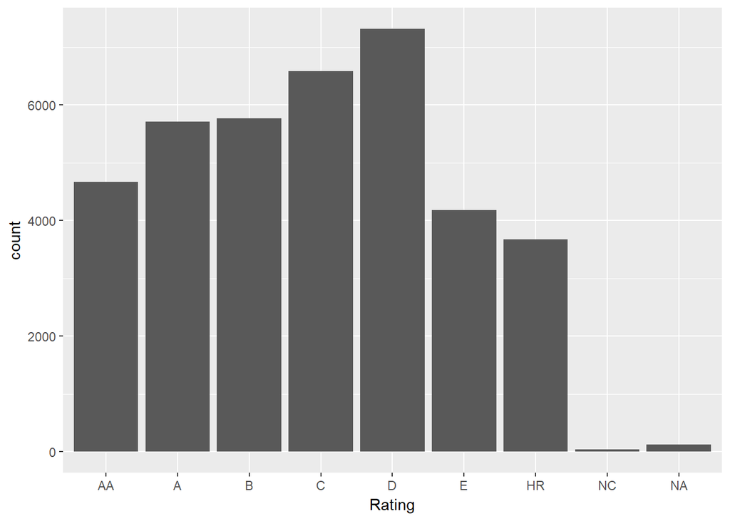

We notice something interesting from these graphs. As expected, the defaulted loans have ratings toward the lower end. However, the completed loans don’t seem to favor one rating vs. another. Now let’s look at employment status.

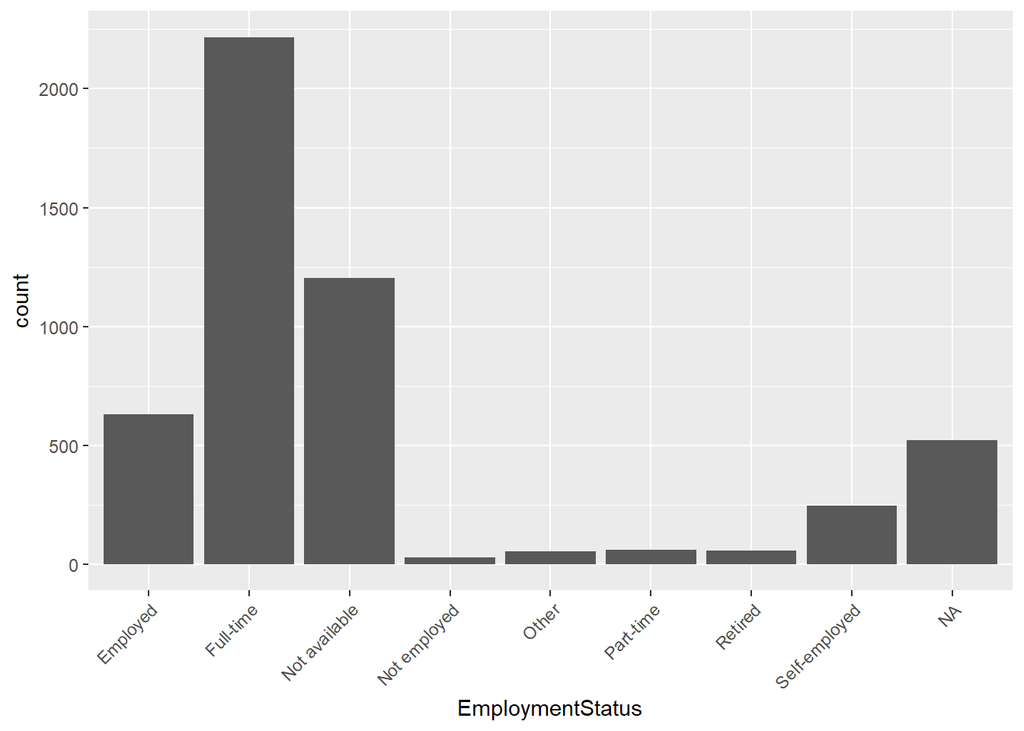

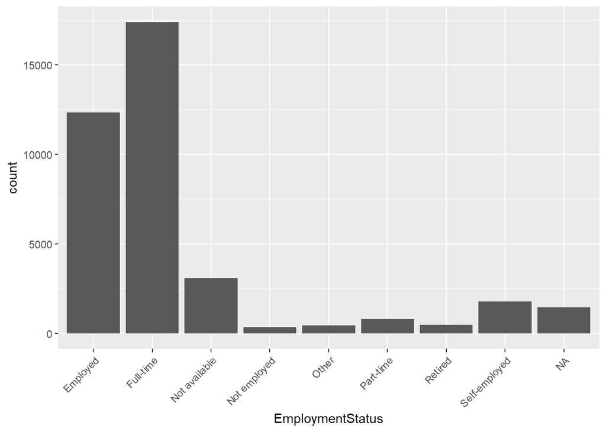

We can see from the above that there isn’t too much a difference in employment status, though the defaults seem to have more ‘not available’ than the completed. Now let’s look at some quantitative variables, namely, credit score of the borrower. We will first average the upper and lower credit scores.

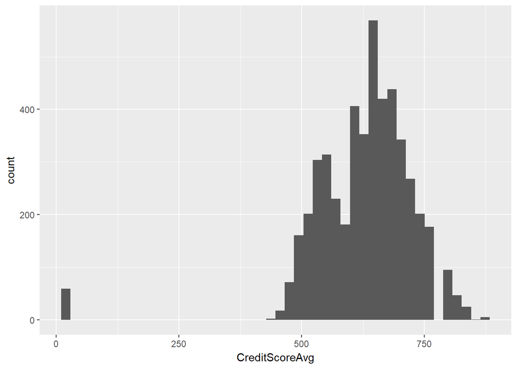

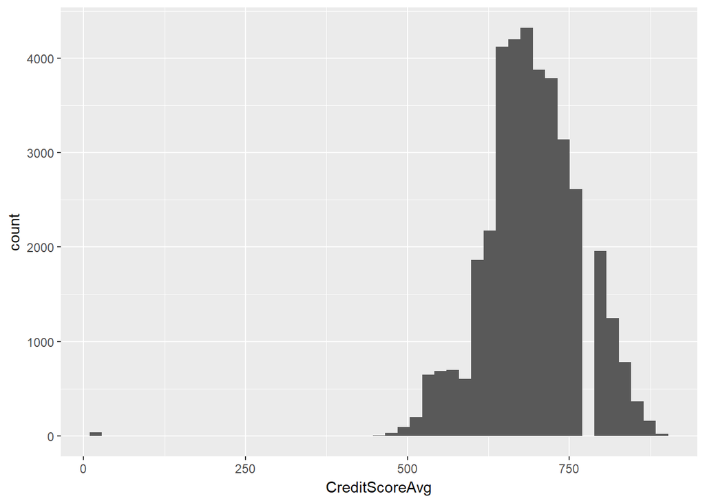

```
## [1] "Mean Credit Score for Defaults 630.440310711365"
```

```
## [1] "Mean Credit Score for Completed Loans 695.087126241436"
```

So we can see from above that the defaults have a lower mean credit score than the completed, which is what we would expect. Now let’s look at monthly income.

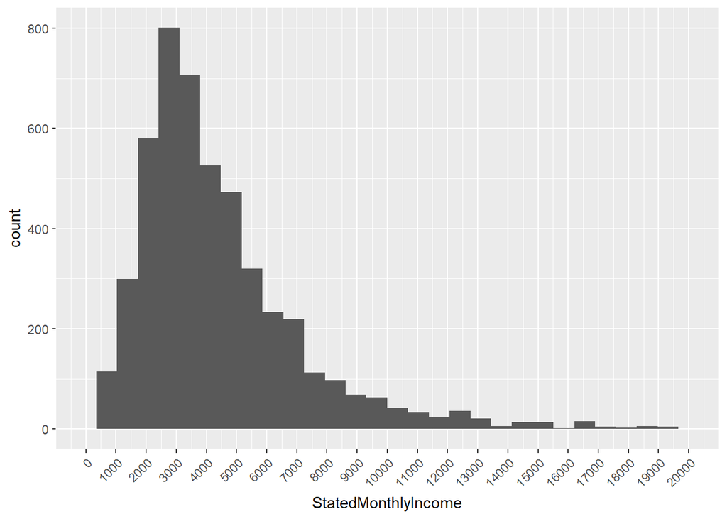

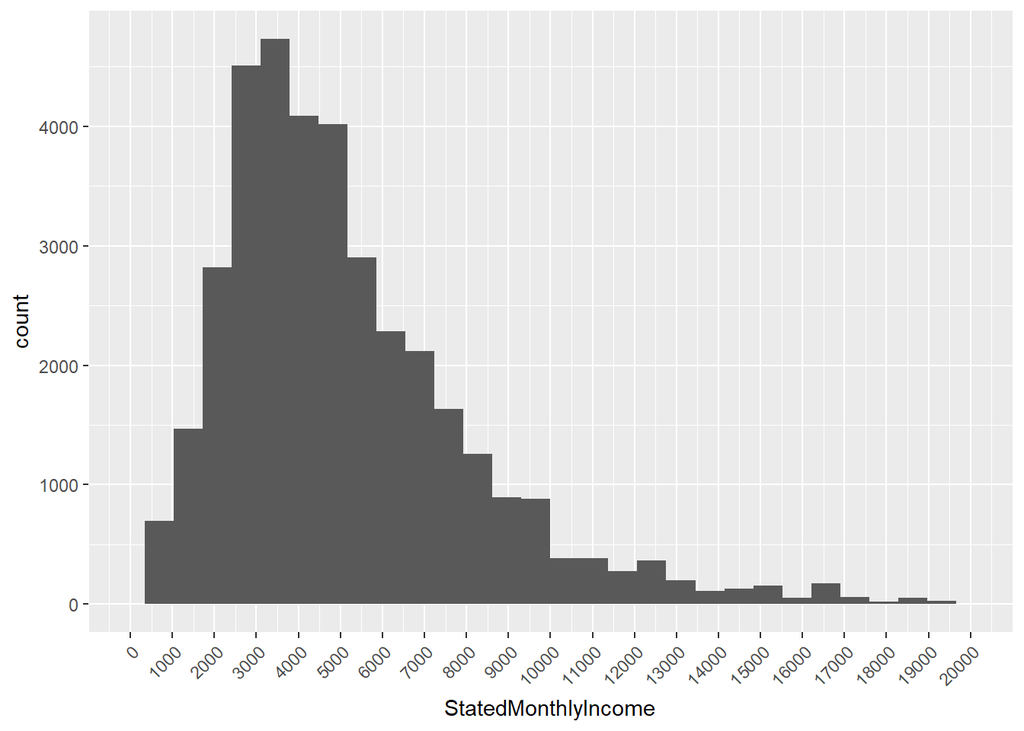

Because these are both very long-tailed distributions, let’s look at the median.

```
## [1] "Median Income for Defaults 3708.333333"
```

```
## [1] "Median Income for Completed Loans 4416.666667"
```

Again, we see that the median monthly income for the completed loans is higher than that of the defaults. Soon we can start building a model to try and predict the probability a loan will default. Next let us look at debt to income ratio.

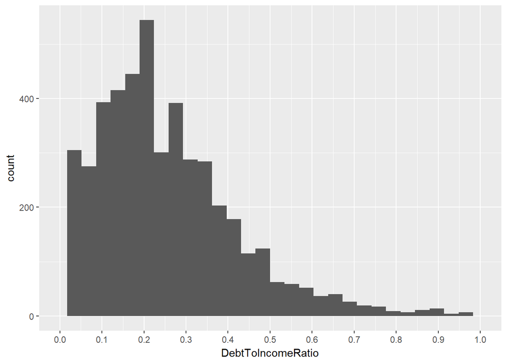

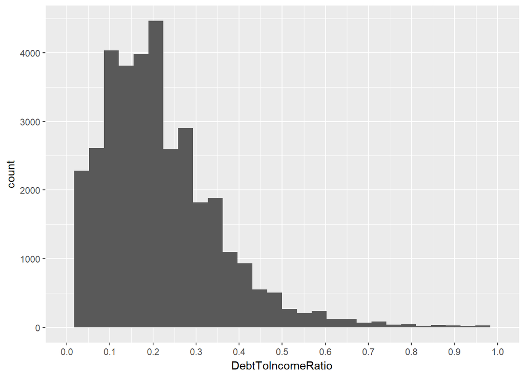

Again, since they are long-tailed, let’s look at the median.

```
## [1] "Defaults: 0.22"
```

```
## [1] "Completed Loans: 0.19"
```

We can see that, once again, the completed loans have a lower debt-to-income ratio than the defaulted loans, this too makes sense.

## Recap so Far

We have found a few interesting things that can help our model. First, defaulted loans tend to have lower ratings than completed loans. Second, the employment status of the borrower doesn’t seem to matter as much, though defaulted loans had higher instances of ‘not available’. Third, the mean credit scores and median monthly income of defaulted loans is less than completed loans. Finally, the median debt-to-income ratio is higher for defaulted loans.

We are going to look at a few more variables. First, the APR of the loan. Second, the number of open credit lines. Third, whether or not the borrower provided verifiable documentation of income. And fourth, the bank card utilization of the borrower.

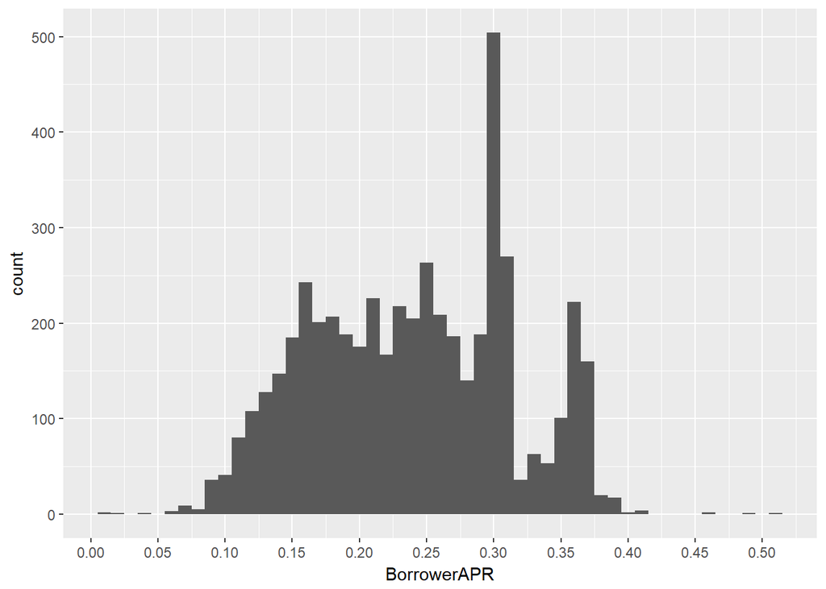

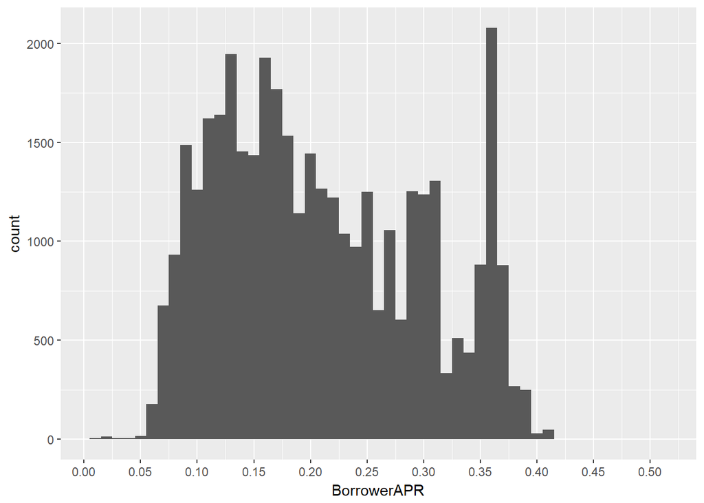

Let’s take a look at the median now.

```
## [1] "Defaults: 0.24001"
```

```
## [1] "Complted Loans: 0.19479"
```

We see here that the defaulted loans tend to have a higher APR than the completed loans. Let’s look through the other variables.

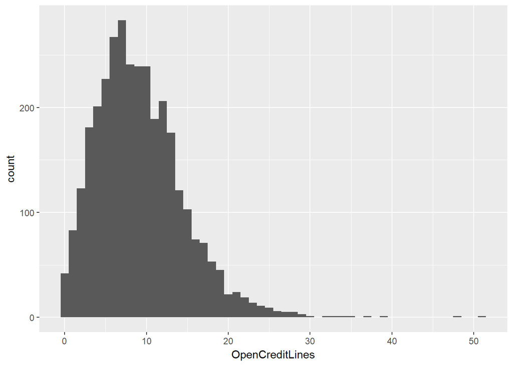

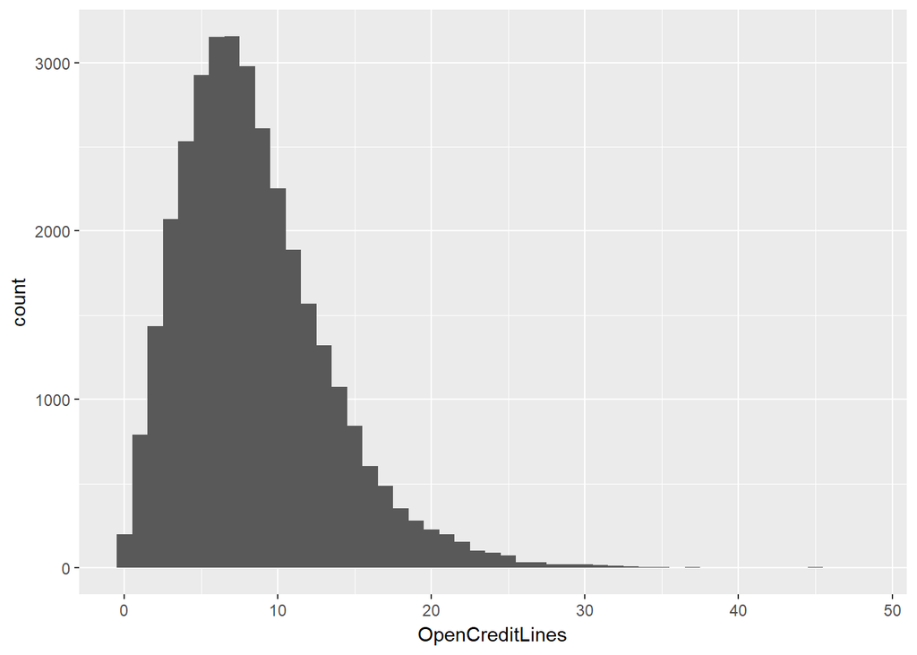

And again, the medians.

```
## [1] "Defaults: 8"
```

```
## [1] "Completed Loans: 8"
```

Here, interestingly, the medians are equal. Let’s see what the means tell us.

```
## [1] "Defaults: 9.16773017319963"
```

```
## [1] "Completed Loans: 8.44992102988944"
```

So it seems that the defaulted loans has a longer tail than the completed lonas, and therefore the mean number of open credit lines is further away from the median than for the completed loans. Now let’s look at the verified income.

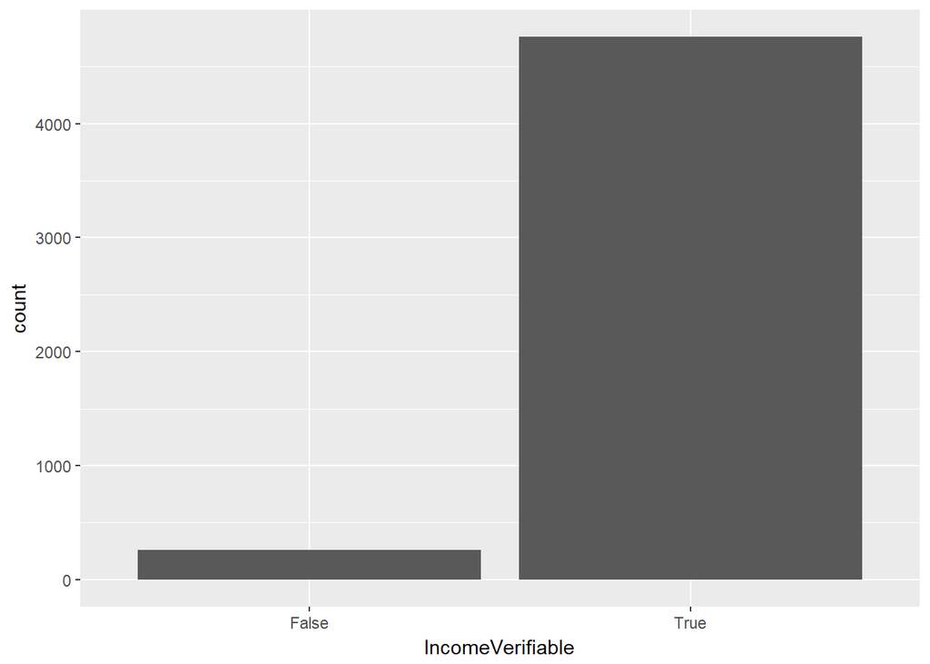

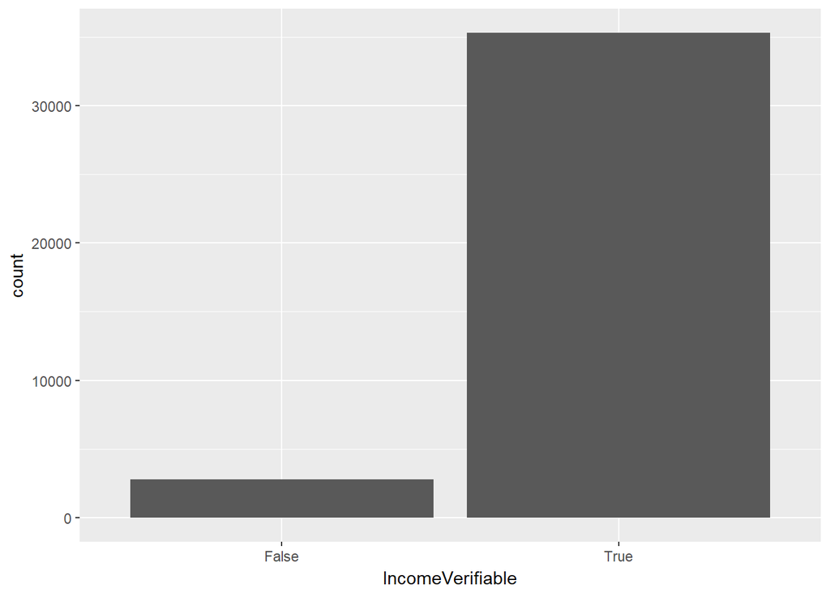

Interestingly, there doesn’t seem to be too much of a difference between defaults and completed loans when it comes to whether or not they have verified income. Finally, we will look at bank card utilization, or, how much the borrower used their credit card.

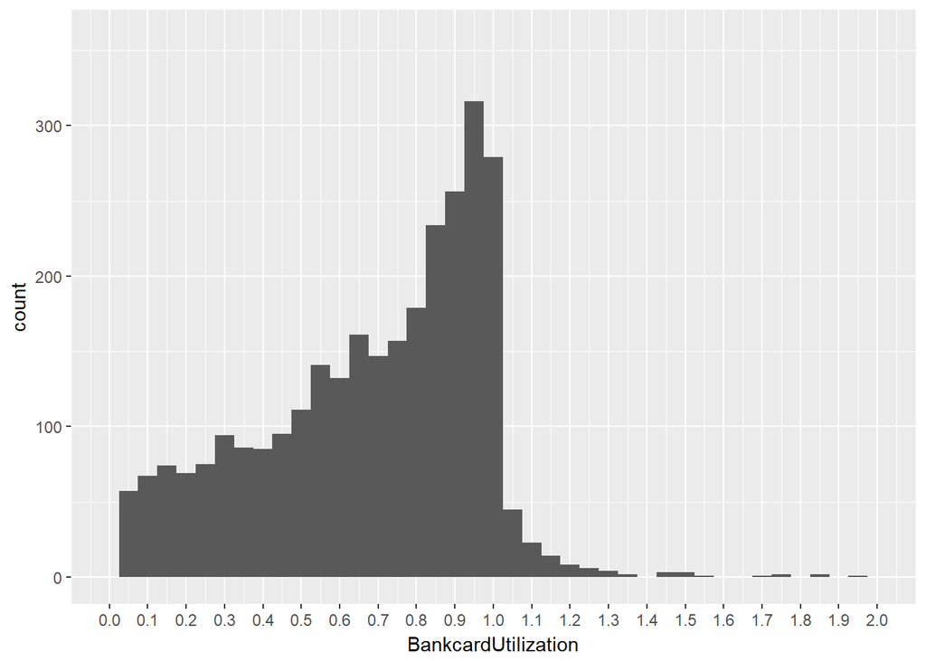

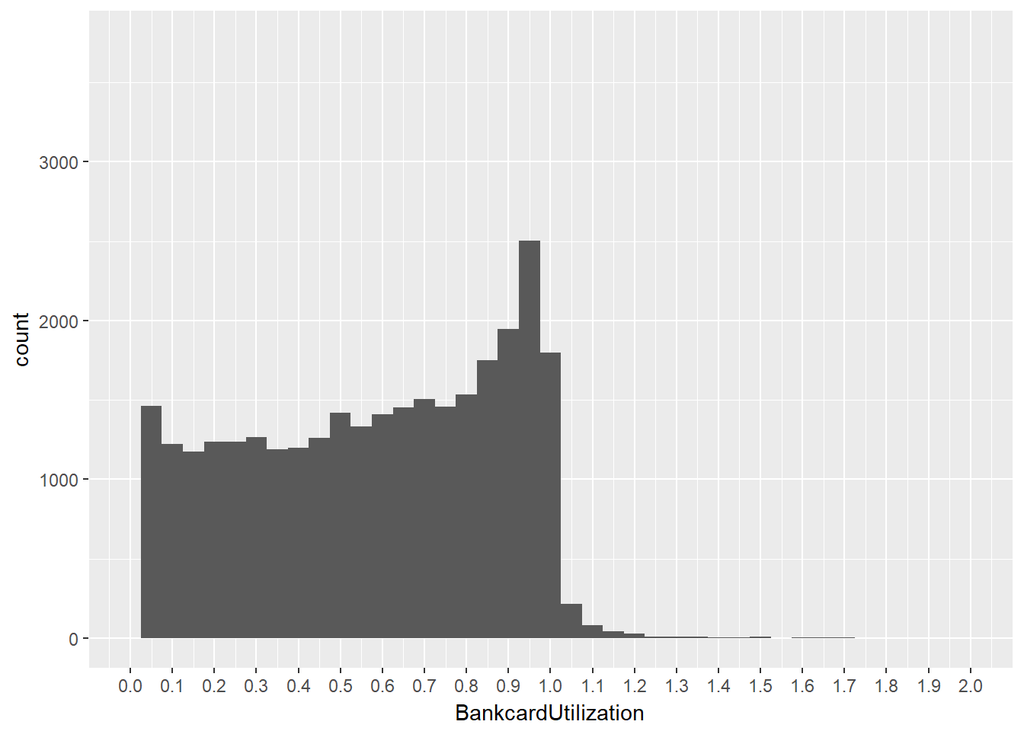

We can see that for defaulted loans, they appear to use a higher percentage of their available bank card credit. Let’s look at medians and means now.

```
## [1] "Means"
```

```
## [1] "Defaults: 0.613339410513522"
```

```
## [1] "Completed Loans: 0.515626247876747"
```

```
## [1] "Medians"
```

```
## [1] "Defaults: 0.69"
```

```
## [1] "Completed Loans: 0.54"
```

So we can see that defaults have both a higher mean and median bank card utilization percentage than completed loans.

Now we have a list of variables that may be useful in our model: the loan rating, the borrower’s credit score, stated monthly income, debt-to-income ratio, open lines of credit, and bank card utilization percentage. Some variables that didn’t appear as useful were: employment status and verifiable income.

## Multivariate Plots

However, before diving into the model, let us look at some bivariate and multivariate plots. This should give us an idea of how the variables interact with each other, and hopefully foreshadow our model’s performance.

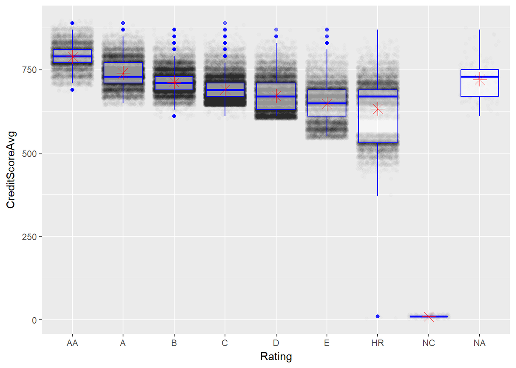

Here we see that, as expected, the lower rated loans have lower average credit scores. This makes sense, as a credit score is basically how risky of a borrower you are, and a loan rating is basically how risky the loan is.

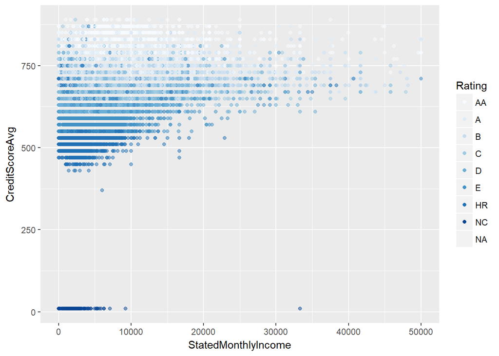

This shows another interesting trend. As monthly income increases, so to does the credit score. Additionally, the loan rating seems to be less reliant on the monthly income than it is on the credit score of the borrower.

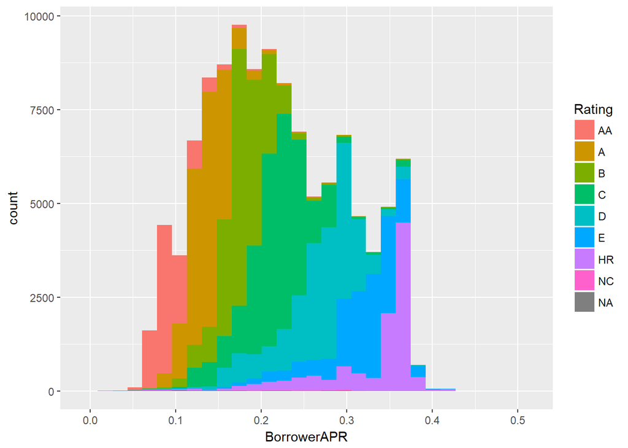

Here we can see another trend: that as APR increases, the quality of loan decreases. This is again expected, since lower quality loans are riskier and a higher interest rate helps offset that risk. Below are some more plots involving credit score, as that is one of the most interesting variables in our data set.

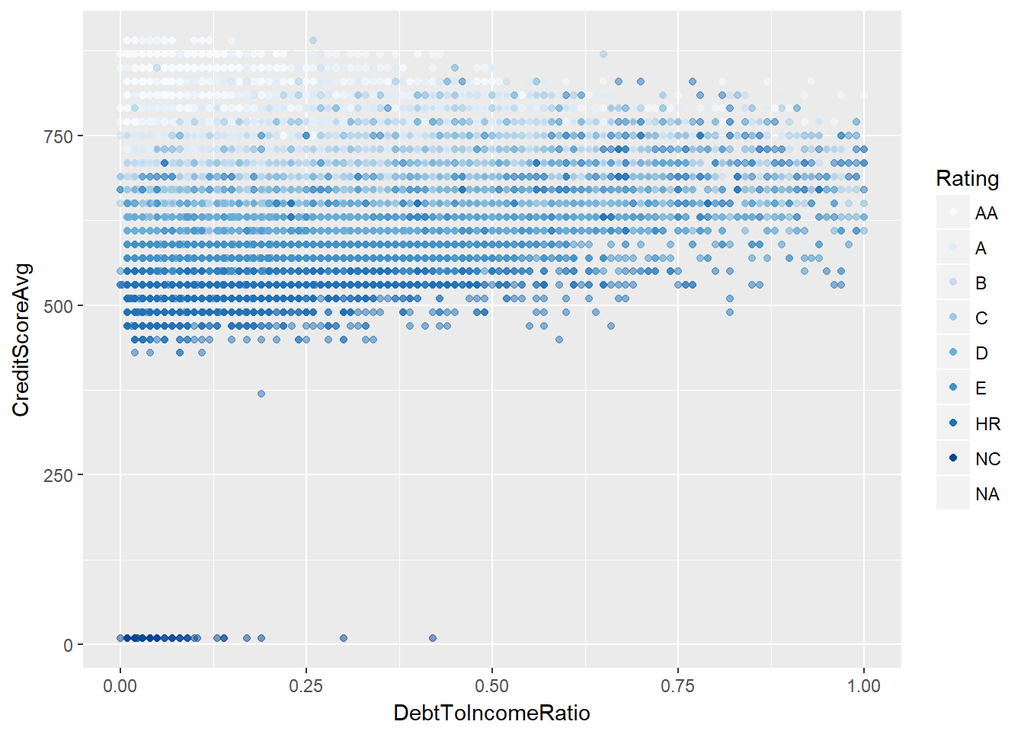

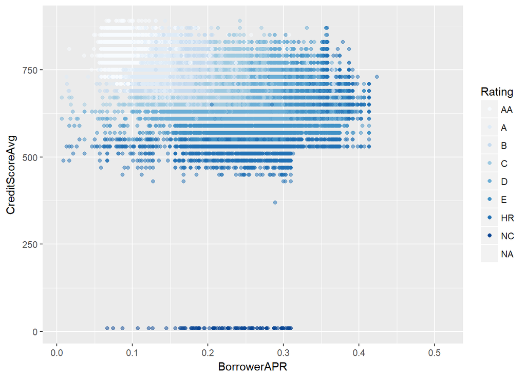

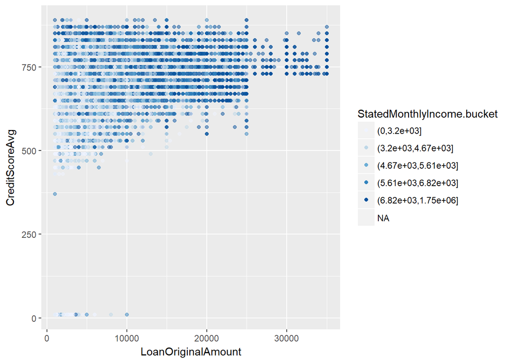

This does not show much of a pattern, though it does show that higher value loans are correlated with higher credit scores. Now onto the model.

## Analysis

I am going to create new data sets that contain only the variables I care about, so that they are easier to work with.

Because the result of a loan is a binary choice, I am going to attempt to use logarithmic regression to create a model that will give the percent chance a loan will default. To do this I will first convert the loan rating into a numeric scale, one that mirrors Prosper’s own numeric rankings.

Since the alphabetical rankings are now redundant, I will drop that column. I will also create a subset that only has the defaulted and completed lonas.

Now I will create a new column that is 0 if the loan is defaulted and 1 if it is completed. Then I will drop the loan status column.

There are some NA values in the data. I will replace these with the mean or, for long-tailed data, the median.

Finally, I will drop any rows that have an NA value for the numeric rating. This is because this is essentially a categorical variable, and taking the mean or median doesn’t make sense.

The next step is to split our data into testing and training subsets. I want an 80/20 train/test split.

```r
splits <- sample(1:nrow(mod_results), size = 0.2*nrow(mod_results))

test <- mod_results[splits,]

train <- mod_results[-splits,]
```

Now to create the model.

```r
model <- glm(result~., family=binomial(link='logit'), data = train)

summary(model)
```

```
##
## Call:
## glm(formula = result ~ ., family = binomial(link = "logit"),
##     data = train)
##
## Deviance Residuals:
##     Min       1Q   Median       3Q      Max
## -2.9904   0.3029   0.4110   0.5200   3.1253
##
## Coefficients:
##                       Estimate Std. Error z value Pr(>|z|)
## (Intercept)         -3.720e+00  2.105e-01 -17.676  < 2e-16 ***
## CreditScoreAvg       1.065e-02  4.087e-04  26.069  < 2e-16 ***
## OpenCreditLines     -4.781e-02  3.854e-03 -12.406  < 2e-16 ***
## BankcardUtilization  6.459e-02  6.135e-02   1.053    0.292
## DebtToIncomeRatio   -1.086e-01  1.967e-02  -5.520 3.39e-08 ***
## StatedMonthlyIncome  4.373e-05  6.317e-06   6.922 4.44e-12 ***
## BorrowerAPR         -2.725e+00  3.440e-01  -7.921 2.36e-15 ***
## rating.numeric      -1.526e-01  2.392e-02  -6.379 1.78e-10 ***
## ---
## Signif. codes:  0 '***' 0.001 '**' 0.01 '*' 0.05 '.' 0.1 ' ' 1
##
## (Dispersion parameter for binomial family taken to be 1)
##
##     Null deviance: 24699  on 34373  degrees of freedom
## Residual deviance: 22518  on 34366  degrees of freedom
## AIC: 22534
##
## Number of Fisher Scoring iterations: 5
```

Now we have our model. From the looks of it, the only variable that appears not significant is Bank Card Utilization. To see how well our model actually does, let us run it on the test data. I am using a 0.5 decision boundry. That is, if the model predicts a 50% probability of success (completed loan), it will be set to that.

```r
test.results <- predict(model,
                        newdata=subset(test, select = c(1:7)),
                        type = 'response')

test.results <- ifelse(test.results > 0.5, 1.0, 0)
#Calculate to accuracy of our model (how often it's prediction
#matched the actual result)
accuracy.error <- mean(test.results != test$result)

print(paste('Accuracy', 1-accuracy.error))
```

```
## [1] "Accuracy 0.882811590829745"
```

Now let’s analyze our result a bit more. I will calculate both its precision and its recall for defaults. That is, how good is our model at predicting defaults?

```r
precision <- sum(test.results == test$result
                 & test$result == 0)/sum(test.results == 0)

recall <- sum(test.results == test$result
              & test$result == 0)/sum(test$result == 0)

print(paste('Precision', precision))
```

```
## [1] "Precision 0.684210526315789"
```

```r
print(paste('Recall', recall))
```

```
## [1] "Recall 0.0254652301665034"
```

## Tweaking the Model

First I am going to remove Bank Card Utilization from the model, as it has a very high p-value. Then I am going to tweak our decision threshold. Currently it sits at 50%, but if there is a 50/50 chance of a loan defaulting, would a bank want to give out that loan? Probably not. I will therefore increase it to a 75% threshold.

```
##
## Call:
## glm(formula = result ~ ., family = binomial(link = "logit"),
##     data = train2)
##
## Deviance Residuals:
##     Min       1Q   Median       3Q      Max
## -3.0057   0.3023   0.4117   0.5227   3.1149
##
## Coefficients:
##                       Estimate Std. Error z value Pr(>|z|)
## (Intercept)         -3.663e+00  2.006e-01 -18.261  < 2e-16 ***
## CreditScoreAvg       1.054e-02  3.997e-04  26.362  < 2e-16 ***
## OpenCreditLines     -4.786e-02  3.796e-03 -12.607  < 2e-16 ***
## DebtToIncomeRatio   -1.126e-01  1.955e-02  -5.757 8.57e-09 ***
## StatedMonthlyIncome  4.500e-05  6.301e-06   7.142 9.18e-13 ***
## BorrowerAPR         -2.638e+00  3.383e-01  -7.796 6.40e-15 ***
## rating.numeric      -1.464e-01  2.367e-02  -6.185 6.19e-10 ***
## ---
## Signif. codes:  0 '***' 0.001 '**' 0.01 '*' 0.05 '.' 0.1 ' ' 1
##
## (Dispersion parameter for binomial family taken to be 1)
##
##     Null deviance: 24897  on 34373  degrees of freedom
## Residual deviance: 22652  on 34367  degrees of freedom
## AIC: 22666
##
## Number of Fisher Scoring iterations: 5
```

[output not shown]

The accuracy is very similar to the previous model. Let us look at precision and recall again.

```
## [1] "Precision (model 2) 0.392156862745098"
```

```
## [1] "Recall (model 2) 0.267489711934156"
```

Now we have captured a lot more of the defaults. Of the total defaults, our model predicted default 25ish% of the time. Additionally, 40% of the defaults it predicted were in fact defaults. Let’s test one final thing. We will create a model based soley off the credit score and the rating given to the loan.

```
##
## Call:
## glm(formula = result ~ ., family = binomial(link = "logit"),
##     data = subset(train2, select = c(1, 6, 7)))
##
## Deviance Residuals:
##     Min       1Q   Median       3Q      Max
## -2.7935   0.3225   0.4199   0.5352   2.8604
##
## Coefficients:
##                  Estimate Std. Error z value Pr(>|z|)
## (Intercept)    -4.1513430  0.1943202 -21.363   <2e-16 ***
## CreditScoreAvg  0.0092894  0.0003539  26.249   <2e-16 ***
## rating.numeric -0.0110880  0.0156846  -0.707     0.48
## ---
## Signif. codes:  0 '***' 0.001 '**' 0.01 '*' 0.05 '.' 0.1 ' ' 1
##
## (Dispersion parameter for binomial family taken to be 1)
##
##     Null deviance: 24897  on 34373  degrees of freedom
## Residual deviance: 22953  on 34371  degrees of freedom
## AIC: 22959
##
## Number of Fisher Scoring iterations: 5
```

```
## [1] "Accuracy (model 3) 0.874665425346212"
```

Our new model is slightly less accurate, but let’s check the precision and recall.

```
## [1] "Precision (model 3) 0.408695652173913"
```

```
## [1] "Recall (model 3) 0.241769547325103"
```

We lost a little recall with out simplified model, but not much. Finally, let us set the decision boundry to 70%.

```
## [1] "Accuracy (model 4) 0.88432445013383"
```

```
## [1] "Precision (model 4) 0.46875"
```

```
## [1] "Recall (model 4) 0.169753086419753"
```

## Wrapping Up (Final Plots and Summary)

To wrap up I will examine the relationship between a couple of the variables from the previous section with multivarite plots. First up is the plot of rating vs average credit score

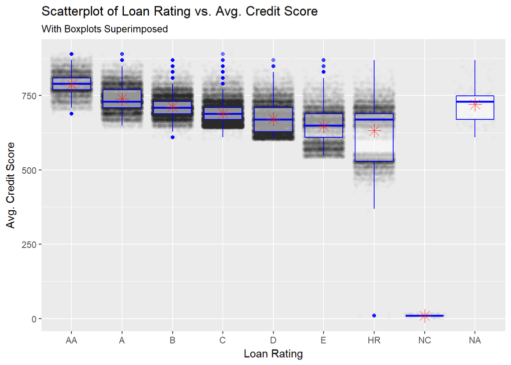

We see here that, as expected, the average credit score decreases as the loan rating decreases. Next up is the scatterplot of monthly income vs average credit score.

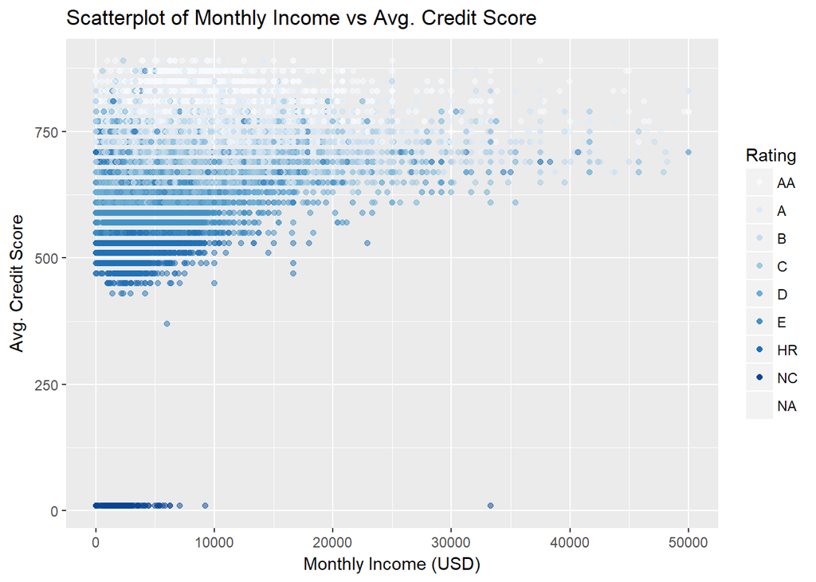

We see again that as income goes up, so too does average credit score, and subsequently loan rating. Finally we have the histogram of APR, with the loan rating as the color.

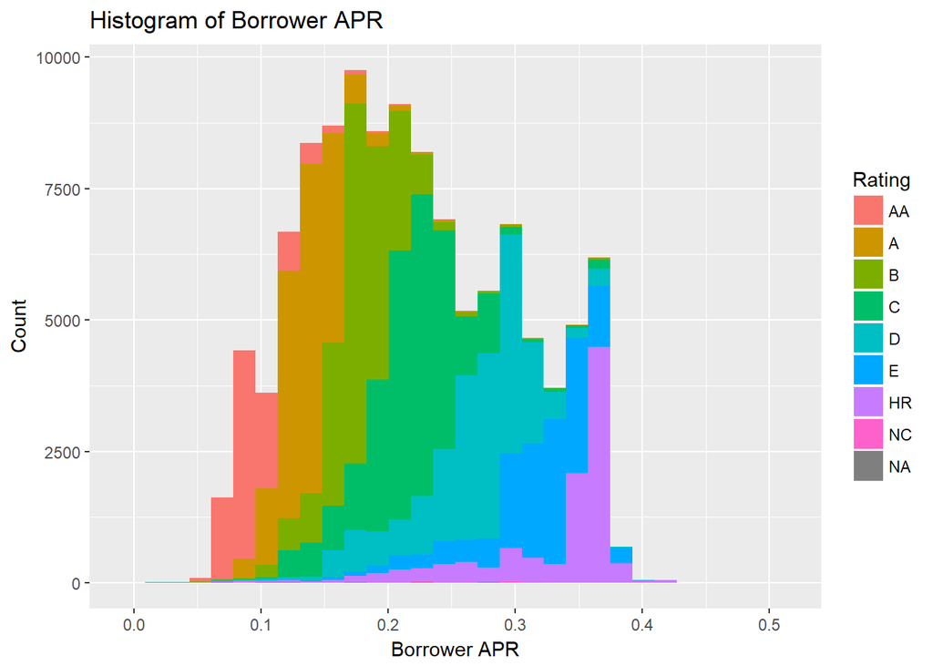

Here we see that as APR increases the loan rating degrades.

From these graphs it is clear that all these variables are very interrelated. In fact, one’s credit score likely takes into account many of these variables. This is one reason the model is less than ideal: it is a very complicated problem to predict. Furthermore, the loan ratings are essentially the company attempting to estimate the risk of default. AA loans are the safest, and HR loans (or NC) are the riskiest. Using the data given, we were able to create a decent model, but because many of the variables influence each other, and defaults are not always caused by individual factors (i.e. national or global economic conditions, which wouldn’t show up in this data), to model leaves some things to be desired.

Despite this, it could be a useful preliminary tool in analyzing a loan. You can be fairly confident that if it predicts a default, one is more likely than you’d like, if you are trying to minimize risk. Overall, we learned a lot about the relationship of the data to the outcome of the loan. Having more data would only improve the model, as well has having more complete data. I hope you found this interesting.

## Reflection

Getting more complete data, which I mentioned previously, would be a huge boon to this investigation. A major problem I encountered was that so many of the loans were ongoing. If I had a longer time span of loans, including many more defaults and completed ones, I am confident my model would be more predictive. As it is, EDA was extremely useful in identifying which variables would be interesting, and in seeing how they interacted with each other and with the result of the loan.